# Input & Convert

Annie Visser-Quinn & Melissa Bedinger

In this vignette, you will find out about inputs and data in `AHgen`:

- Section 1 - Data types
- Section 2 - Read in data
- Section 3 - Check the data
- Section 4 - Convert to different data types
- Section 5 - Navigate the data using the `tidyverse` and `igraph` packages

To navigate to other vignettes, go to Vignette 0 - Welcome to AHgen.

## 1. Data types

### 1.1 What is an adjacency matrix?

An [adjacency matrix](https://proofwiki.org/wiki/Definition:Adjacency_Matrix) is a matrix which describes a network by representing which vertices are adjacent (i.e. connected) to which other vertices. If there are N vertices in a network, there are N columns (one for each vertex) and N rows (one for each vertex) in the matrix. Each cell of the matrix includes number signifying the connection between the two vertices, representing a potential edge or link.

An adjacency matrix for a simple graph has elements which are all either 0 (representing no connection between the two vertices) or 1 (representing a connection between the two vertices). This is a binary representation of a network. An adjacency matrix for a weighted network contains the weights of the edges (e.g. a weight of 0.75). A higher weight represents a stronger connection than a lower weight (e.g. an edge with a weight of 0.75 is stronger than an edge with a weight of 0.25).

Abstraction Hierarchies are treated as undirected graphs, thus an adjacency matrix for an Abstraction Hierarchy is symmetrical about the main diagonal.

*An example adjacency matrix*

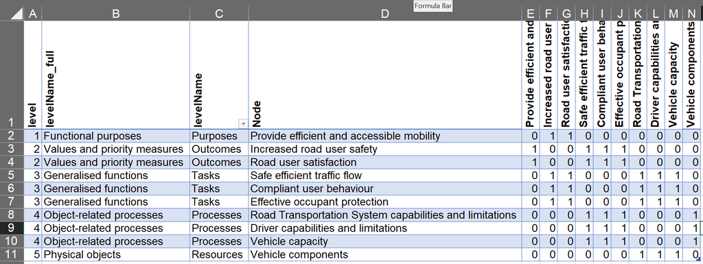

### 1.2 What is an edgelist?

An [edge list](https://en.wikipedia.org/wiki/Edge_list) is a data structure which describes a network by listing each connection as a row of information. The first column describe the vertex the edge is coming ‘from’, the second column describes the vertex the edge is coming ‘to’, and if it is a weighted network the third column gives the numeric value of the ‘weight’. In an undirected network such as the Abstraction Hierarchy, the ‘from’ and ‘to’ columns are merely representative of an undirected edge between two vertices rather than literally being ‘from’ and ‘to’ one vertex or another.

*An example edge list*

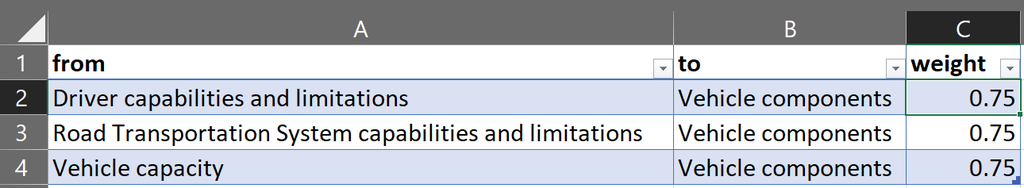

### 1.3 What is an igraph?

An igraph is an object class from the package of the same name. The igraph data type is a special way of formatting complex networks, enabling the creation of large networks and speedy application of network analysis.

The code output below is an *igraph of an abstraction hierarchy*.

```
## IGRAPH d5cf938 UNW- 25 35 --
## + attr: name (v/c), level (v/n), levelName_full (v/c), levelName (v/c),
## | weight (e/n), layer (e/c)
## + edges from d5cf938 (vertex names):
##  [1] To cook food     --Time to heat food
##  [2] To cook food     --Ease of cooking
##  [3] To cook food     --Even dissipation of heat
##  [4] To cook food     --Minimise environmental impact
##  [5] To cook food     --Minimise energy use
##  [6] Time to heat food--Generate heat
##  [7] Time to heat food--Monitor condition of food
## + ... omitted several edges
```

The first line states that this is an igraph. It also provides a codename for the graph, *UNW-*:

- **U** The graph is **U**ndirected
- **N** The vertices have **N**ames
- **W** The **W**eight attribute has been set
- **-** The graph is not bipartite

The second line provides the attributes of the **vertices** (denoted as **v**) and **edges** (denoted as **e**):

- **name (v/c)** - The vertices are named, and have the class **c**, character.
- **level (v/n)** - The vertices have an attribute called **level**, with the class **n**, numeric. This denotes which level (from 1 through 5) a vertex belongs to.
- **levelName_full (v/c)** - The vertices have an attribute called **levelName_full**, with the class **c**, character. This gives the full level name in human factors and Cognitive Work Analysis terminology (from ‘Functional purposes’ through ‘Physical objects’).
- **levelName (v/c)** - The vertices have an attribute called **levelName**, with the class **c**, character. This gives a more concise level name (from ‘Purposes’ through ‘Resources’).
- **weight (e/n)** - The edges have a weight, with the class **n**, numeric.
- **layer (e/c)** - The edges have an attribute called **layer**, with the class **c**, character.

The remainder of the output represents the edges and the vertex names.

## 2. Read in data

Here we focus on the two functions, `read_adjMat()` and `read_vInfo()`, which read in the main inputs to `AHgen`:

- An **adjacency matrix** capturing the edges between the levels of the abstraction hierarchy.
- **Vertex information** describing the level and level name associated with each vertex. These inputs should be in the .xlsx or .csv format, i.e. an Excel spreadsheet.

### 2.1 Adjacency matrix

The adjacency matrix can be read in using the function `read_adjMat()`. This function has three input arguments:

- `filename` - The file path (relative to the `AHgen` folder).
- `sheet` - The sheet number of the adjacency matrix; this is set to `sheet = 1` by default.
- `rescale` - Whether the edge weightings in the adjacency matrix should be rescaled to 0.5. This is sometimes useful for testing the hypothetical degradation of an Abstraction Hierarchy network. This is set to `rescale = FALSE` by default. *Note, two of the three `read_adjMat()` input arguments have default values. If only the filename is provided, these arguments will take this default value.*

Click below to explore two example applications.

**Show code - Example 1 - Read adjacency matrix input (microwave)**

1. The column of vertex names must be named **Node**.
2. Vertex names run left to right.
3. And top to bottom.
4. The **edges** between vertices are denoted by cells with a value of **1**. **Non-edges** are denoted by **empty** cells. *Note, zeroes can also be used to indicate non-edges*.
5. The diagonal cannot be linked i.e. a vertex cannot link to itself.

```r
read_adjMat("inputs/microwaveAH_adjMat_20230629.xlsx")
```

```
## # A tibble: 25 × 29
##    level levelName_full       levelName Node  `To cook food` `Time to heat food`
##    <dbl> <chr>                <chr>     <chr>          <dbl>               <dbl>
##  1     1 Functional purposes  Purposes  To c…              0                   1
##  2     2 Values and priority… Outcomes  Time…              1                   0
##  3     2 Values and priority… Outcomes  Ease…              1                   0
##  4     2 Values and priority… Outcomes  Even…              1                   0
##  5     2 Values and priority… Outcomes  Mini…              1                   0
##  6     2 Values and priority… Outcomes  Mini…              1                   0
##  7     3 Generalised functio… Tasks     Gene…              0                   1
##  8     3 Generalised functio… Tasks     Moni…              0                   1
##  9     3 Generalised functio… Tasks     Cont…              0                   1
## 10     3 Generalised functio… Tasks     Cont…              0                   1
## # ℹ 15 more rows
## # ℹ 23 more variables: `Ease of cooking` <dbl>,
## #   `Even dissipation of heat` <dbl>, `Minimise environmental impact` <dbl>,
## #   `Minimise energy use` <dbl>, `Generate heat` <dbl>,
## #   `Monitor condition of food` <dbl>, `Control heat transfer to food` <dbl>,
## #   `Control dissipation of heat` <dbl>, `Generate radio waves` <dbl>,
## #   `Generate light` <dbl>, `Set level of power` <dbl>, `Support food` <dbl>, …
```

Notice that the empty cells from the Excel file are filled with zeroes by `AHgen`. This means these vertices are not linked, i.e. they have no weight. We might want to rescale the linked, or weighted edges, to 0.5. To do this, change the `rescale` argument to `TRUE`.

```r
read_adjMat("inputs/microwaveAH_adjMat_20230629.xlsx", rescale = TRUE)
```

```
## # A tibble: 25 × 29
##    level levelName_full       levelName Node  `To cook food` `Time to heat food`
##    <dbl> <chr>                <chr>     <chr>          <dbl>               <dbl>
##  1     1 Functional purposes  Purposes  To c…            0                   0.5
##  2     2 Values and priority… Outcomes  Time…            0.5                 0
##  3     2 Values and priority… Outcomes  Ease…            0.5                 0
##  4     2 Values and priority… Outcomes  Even…            0.5                 0
##  5     2 Values and priority… Outcomes  Mini…            0.5                 0
##  6     2 Values and priority… Outcomes  Mini…            0.5                 0
##  7     3 Generalised functio… Tasks     Gene…            0                   0.5
##  8     3 Generalised functio… Tasks     Moni…            0                   0.5
##  9     3 Generalised functio… Tasks     Cont…            0                   0.5
## 10     3 Generalised functio… Tasks     Cont…            0                   0.5
## # ℹ 15 more rows
## # ℹ 23 more variables: `Ease of cooking` <dbl>,
## #   `Even dissipation of heat` <dbl>, `Minimise environmental impact` <dbl>,
## #   `Minimise energy use` <dbl>, `Generate heat` <dbl>,
## #   `Monitor condition of food` <dbl>, `Control heat transfer to food` <dbl>,
## #   `Control dissipation of heat` <dbl>, `Generate radio waves` <dbl>,
## #   `Generate light` <dbl>, `Set level of power` <dbl>, `Support food` <dbl>, …
```

**Show code - Example 2 - Read adjacency matrix input (mobility)**

We now consider a second example abstraction hierarchy, *mobilityAH_adjMat_20230629.xlsx*, which is also available in the *inputs* folder.

1. As before, the column of vertex names is called **Node**.
2. And the vertex names run left to right.
3. And top to bottom.
4. The **edges** between vertices are again denoted by cells with a value of **1**. This time, **non-edges** are denoted by **0** cells.
5. But there are three extra columns of vertex information, **level**, **levelName_full**, and **levelName**. If these columns had different names they would be read in as vertices!

With only one sheet, the first sheet is the adjacency matrix, and if we don’t want to rescale the data, then only one input argument is required `"inputs/mobilityAH_adjMat_20230629.xlsx"`.

```r
read_adjMat("inputs/mobilityAH_adjMat_20230629.xlsx")
```

```
## # A tibble: 10 × 14
##    level levelName_full               levelName Node      Provide efficient an…¹
##    <dbl> <chr>                        <chr>     <chr>                      <dbl>
##  1     1 Functional purposes          Purposes  Provide …                      0
##  2     2 Values and priority measures Outcomes  Increase…                      1
##  3     2 Values and priority measures Outcomes  Road use…                      1
##  4     3 Generalised functions        Tasks     Safe eff…                      0
##  5     3 Generalised functions        Tasks     Complian…                      0
##  6     3 Generalised functions        Tasks     Effectiv…                      0
##  7     4 Object-related processes     Processes Road Tra…                      0
##  8     4 Object-related processes     Processes Driver c…                      0
##  9     4 Object-related processes     Processes Vehicle …                      0
## 10     5 Physical objects             Resources Vehicle …                      0
## # ℹ abbreviated name: ¹`Provide efficient and accessible mobility`
## # ℹ 9 more variables: `Increased road user safety` <dbl>,
## #   `Road user satisfaction` <dbl>, `Safe efficient traffic flow` <dbl>,
## #   `Compliant user behaviour` <dbl>, `Effective occupant protection` <dbl>,
## #   `Road Transportation System capabilities and limitations` <dbl>,
## #   `Driver capabilities and limitations` <dbl>, `Vehicle capacity` <dbl>,
## #   `Vehicle components` <dbl>
```

The code chunk below shows what happens if there is a mismatch in column names. Check out the file *mobilityAH_error_adjMat_20230629.xlsx* to see if you can spot the problem.

```r
read_adjMat("inputs/mobilityAH_error_adjMat_20230629.xlsx")
```

```
## # A tibble: 10 × 14
##    Node              Level `Level name full` `Level name` Provide efficient an…¹
##    <chr>             <dbl>             <dbl>        <dbl>                  <dbl>
##  1 Provide efficien…     1                 0            0                      0
##  2 Increased road u…     2                 0            0                      1
##  3 Road user satisf…     2                 0            0                      1
##  4 Safe efficient t…     3                 0            0                      0
##  5 Compliant user b…     3                 0            0                      0
##  6 Effective occupa…     3                 0            0                      0
##  7 Road Transportat…     4                 0            0                      0
##  8 Driver capabilit…     4                 0            0                      0
##  9 Vehicle capacity      4                 0            0                      0
## 10 Vehicle componen…     5                 0            0                      0
## # ℹ abbreviated name: ¹`Provide efficient and accessible mobility`
## # ℹ 9 more variables: `Increased road user safety` <dbl>,
## #   `Road user satisfaction` <dbl>, `Safe efficient traffic flow` <dbl>,
## #   `Compliant user behaviour` <dbl>, `Effective occupant protection` <dbl>,
## #   `Road Transportation System capabilities and limitations` <dbl>,
## #   `Driver capabilities and limitations` <dbl>, `Vehicle capacity` <dbl>,
## #   `Vehicle components` <dbl>
```

### 2.2 Vertex information

The vertex information can be read in using the function `read_vInfo()`. This function has two input arguments:

- `filename` - The file path (relative to the `AHgen` folder).
- `sheet` - The sheet number of the vertex information. This is set to `sheet = 1` by default.

**Show code - Example 3 - Read vInfo input (microwave)**

```r
read_vInfo("inputs/microwaveAH_vInfo_20230629.xlsx")
```

```
## # A tibble: 25 × 4
##    level levelName_full               levelName Node
##    <dbl> <chr>                        <chr>     <chr>
##  1     1 Functional purposes          Purposes  To cook food
##  2     2 Values and priority measures Outcomes  Time to heat food
##  3     2 Values and priority measures Outcomes  Ease of cooking
##  4     2 Values and priority measures Outcomes  Even dissipation of heat
##  5     2 Values and priority measures Outcomes  Minimise environmental impact
##  6     2 Values and priority measures Outcomes  Minimise energy use
##  7     3 Generalised functions        Tasks     Generate heat
##  8     3 Generalised functions        Tasks     Monitor condition of food
##  9     3 Generalised functions        Tasks     Control heat transfer to food
## 10     3 Generalised functions        Tasks     Control dissipation of heat
## # ℹ 15 more rows
```

**Show code - Example 4 - Read vInfo input (mobility)**

We saw in Example 2 that the vertex information was embedded in the adjacency matrix. This can be extracted using the `tidyverse` function `select`.

```r
read_adjMat("inputs/mobilityAH_adjMat_20230629.xlsx") %>%
  select(level, levelName_full, levelName, Node)
```

```
## # A tibble: 10 × 4
##    level levelName_full               levelName Node
##    <dbl> <chr>                        <chr>     <chr>
##  1     1 Functional purposes          Purposes  Provide efficient and accessibl…
##  2     2 Values and priority measures Outcomes  Increased road user safety
##  3     2 Values and priority measures Outcomes  Road user satisfaction
##  4     3 Generalised functions        Tasks     Safe efficient traffic flow
##  5     3 Generalised functions        Tasks     Compliant user behaviour
##  6     3 Generalised functions        Tasks     Effective occupant protection
##  7     4 Object-related processes     Processes Road Transportation System capa…
##  8     4 Object-related processes     Processes Driver capabilities and limitat…
##  9     4 Object-related processes     Processes Vehicle capacity
## 10     5 Physical objects             Resources Vehicle components
```

## 3. Check the data

There are several `AHgen` functions to perform checks on data and outputs. Here we focus on the functions to check raw data after it has been read in from a spreadsheet format. These are `check_symmetry`, `check_redundancy`, and `check_names`.

**Show code - Example 5 - Check symmetry**

The `check_symmetry` function confirms that an adjacency matrix has completely symmetrical edges. This is most important for an undirected graph where an adjacency matrix must be symmetrical along its diagonal. If the adjacency matrix is not symmetrical, `check_symmetry` will return a data frame of inconsistent edges to check.

```r
# Confirm adjMat has completely symmetrical edges i.e. there are no input errors
dh_USAH =
  read_adjMat("inputs/USAH_3.0_template_baseline_adjMat_20230602.xlsx")

symmetryCheck = dh_USAH %>% check_symmetry()
```

```
## [1] "All edges are symmetrical. Proceed!"
```

```r
# See what happens when a few of the edges in the adjacency matrix are unsymmetrical
dh_USAH_error =
  read_adjMat(
  "inputs/USAH_3.0_template_baseline_error-symmetry_adjMat_20230602.xlsx")

symmetryCheck_error = dh_USAH_error %>% check_symmetry()
```

```
## [1] "Not all edges are symmetrical. Inspect 'check' object and make corrections in adjMat input file."
```

```r
symmetryCheck_error
```

```
##                                        Node
##  1: Administrate provision of potable water
##  2: Administrate provision of potable water
##  3:                  Water tanks and towers
##  4:                  Water tanks and towers
##  5:                   Water treatment works
##  6:                   Water treatment works
##  7:                                Wetlands
##  8:                                Wetlands
##  9:                                Wildlife
## 10:                                Wildlife
##     Administrate provision of potable water Water tanks and towers
##  1:                                      NA                      1
##  2:                                      NA                      0
##  3:                                       0                     NA
```

[output cut: 18 more lines]

**Show code - Example 6 - Check redundancy**

The `check_redundancy` function confirms that an adjacency matrix has no vertices which with redundant sets of edges. In the development of the Urban Systems Abstraction Hierarchy, a guiding principle of development was that if two Resources were connected to the same set of Processes, the two Resources should be combined. For example, if *Coworking office spaces* and *Offices (other)* fulfilled the same Processes, these were combined into an umbrella Resource. If the adjacency matrix contains vertices with redundant sets of edges, `check_redundancy` will return a dataframe of these vertices to check.

```r
# Confirm adjMat has no vertices with redundant sets of edges i.e. no vertices
# are connected to the same set of other vertices between two levels
dh_USAH =
  read_adjMat("inputs/USAH_3.0_template_baseline_adjMat_20230602.xlsx")

redundancyCheck = dh_USAH %>% check_redundancy()
```

```
## [1] "All edge sets are unique. Proceed!"
```

```r
# See what happens when a few of the edges in the adjacency matrix are unsymmetrical
dh_USAH_error =
  read_adjMat(
    "inputs/USAH_3.0_template_baseline_error-redundancy_adjMat_20230602.xlsx")

redundancyCheck_error = dh_USAH_error %>% check_redundancy()
```

```
## [1] "The following redundant edge sets have been found: Coworking office spaces"
## [2] "The following redundant edge sets have been found: Offices (other)"
## [1] "Make corrections in adjMat input file. Either combine vertices with redundant edge sets, or adjust linking to reflect differences between vertices."
```

Note that in the correct Urban Systems Abstraction Hierarchy, the difference between *Coworking office spaces* and *Offices (other)* are that: - *Coworking office spaces* fulfils the Process *Provides other discretionary services* while *Offices (other)* does not - *Offices (other)* fulfils the Process *Provides IT services* while *Coworking office spaces* does not

**Show code - Example 7 - Check names**

In applications of `AHgen` to the Urban Systems Abstraction Hierarchy, outputs from another software `OSMtidy` are sometimes used. `OSMtidy` outputs give a tidy dataset of geospatial data (individual points, lines, and polygons representing different buildings, parks, etc.). Each observation of geospatial data is described by a *desc* term, such as *Attractions; Soft play* and *Sports and recreation; Indoor playground*. In `AHgen`, these *desc* terms are matched to Abstraction Hierarchy Resources in an aggregated manner - in this case the Resource *Playgrounds (indoor)*.

The `check_names` function confirms that *desc* name and the *Resource* name are both matched in a key. If there are any unmatched names (an additional *desc* term in the `OSMtidy` output, or an additional vertex in the Abstraction Hierarchy), `check_names` will return a dataframe of these to check. Usually this means that a new *desc* term or changed Resource name needs to be added to the key; in some cases an adjustment to the USAH has been made but a spelling error exists, and this check catches it before any issues arise in further `AHgen` analysis.

```r
# Read in adjacency matrix
dh_USAH =
  read_adjMat("inputs/USAH_3.0_template_baseline_adjMat_20230602.xlsx")

# Read in vInfo
dv_USAH =
  read_vInfo("inputs/USAH_3.0_template_baseline_vInfo-full_20230621.xlsx")

# Read in key to match names from one software package (OSMtidy)
# to names in another software package (AHgen)
key = read_csv(
  "inputs/OSM-AH-key_3.0_20230717.csv", show_col_types = FALSE)

# Check that all the names match and return any that do not match
nameCheck_correct =
  check_names(adjMat_template = dh_USAH, vInfo_template = dv_USAH, key = key)
```

```
## [1] "Node names from inputs match. Proceed!"
```

```r
# See what happens when there is a non-matching name
# Read in adjacency matrix
dh_USAH_error =
  read_adjMat(
    "inputs/USAH_3.0_template_baseline_error-names_adjMat_20230602.xlsx")

# Read in vInfo
dv_USAH_error =
  read_vInfo(
    "inputs/USAH_3.0_template_baseline_error-names_vInfo-full_20230621.xlsx")

# Read in key to match names from one software package (OSMtidy)
# to names in another software package (AHgen)
key = read_csv(
  "inputs/OSM-AH-key_3.0_20230717.csv", show_col_types = FALSE)

# Check that all the names match and return any that do not match
nameCheck_error =
  check_names(
    adjMat_template = dh_USAH_error, vInfo_template = dv_USAH_error, key = key)
```

```
## [1] "Some Node names do not match. Please inspect and revise input data."
## # A tibble: 1 × 5
##   level Node   adjMat vInfo_full key
##   <dbl> <chr>  <chr>  <chr>      <chr>
## 1     5 Tardis TRUE   TRUE       <NA>
```

The object `nameCheck_error` lets us know that there is one item present in the Abstraction Hierarchy Resources level, that is not present in the key: *Tardis*.

## 4. Convert to different data types

In `AHgen`, the abstraction hierarchy can be captured in three different formats:

- Adjacency matrix
- Edge list
- igraph

To change format, `AHgen` has a family of six conversion functions:

- `adjMat_to_edgelist()` and `adjMat_to_igraph()`, where the input arguments are the adjacency matrix
- `edgelist_to_igraph()` and `edgelist_to_adjMat()`, where the input arguments are the abstraction hierarchy in edge list format, and the vertex information
- `igraph_to_adjMat()` and `igraph_to_edgelist()`, where the input arguments are the abstraction hierarchy in the igraph format

Before introducing the examples, we need to save the adjacency matrix and vertex information as objects in the environment. We do this using the `<-` or `=` operators.

```r
dh = read_adjMat("inputs/mobilityAH_adjMat_20230629.xlsx")
dv = dh %>% select(level, levelName_full, levelName, Node)
```

**Show code - Example 8 - Convert from adjacency matrix**

```r
de = dh %>% adjMat_to_edgelist(vInfo = dv); de
```

```
## # A tibble: 20 × 4
##    layer      from                                                  to    weight
##    <chr>      <chr>                                                 <chr>  <dbl>
##  1 l1FP_l2VPM Provide efficient and accessible mobility             Incr…      1
##  2 l1FP_l2VPM Provide efficient and accessible mobility             Road…      1
##  3 l2VPM_l3GF Increased road user safety                            Comp…      1
##  4 l2VPM_l3GF Increased road user safety                            Effe…      1
##  5 l2VPM_l3GF Increased road user safety                            Safe…      1
##  6 l2VPM_l3GF Road user satisfaction                                Comp…      1
##  7 l2VPM_l3GF Road user satisfaction                                Effe…      1
##  8 l2VPM_l3GF Road user satisfaction                                Safe…      1
##  9 l3GF_l4ORP Compliant user behaviour                              Driv…      1
## 10 l3GF_l4ORP Compliant user behaviour                              Road…      1
## 11 l3GF_l4ORP Compliant user behaviour                              Vehi…      1
## 12 l3GF_l4ORP Effective occupant protection                         Driv…      1
## 13 l3GF_l4ORP Effective occupant protection                         Road…      1
## 14 l3GF_l4ORP Effective occupant protection                         Vehi…      1
## 15 l3GF_l4ORP Safe efficient traffic flow                           Driv…      1
## 16 l3GF_l4ORP Safe efficient traffic flow                           Road…      1
## 17 l3GF_l4ORP Safe efficient traffic flow                           Vehi…      1
## 18 l4ORP_l5PO Driver capabilities and limitations                   Vehi…      1
## 19 l4ORP_l5PO Road Transportation System capabilities and limitati… Vehi…      1
## 20 l4ORP_l5PO Vehicle capacity                                      Vehi…      1
```

```r
di = dh %>% adjMat_to_igraph(vInfo = dv); di
```

```
## IGRAPH e3eb293 UNW- 10 20 --
## + attr: name (v/c), level (v/n), levelName_full (v/c), levelName (v/c),
## | weight (e/n), layer (e/c)
## + edges from e3eb293 (vertex names):
## [1] Provide efficient and accessible mobility--Increased road user safety
## [2] Provide efficient and accessible mobility--Road user satisfaction
## [3] Increased road user safety               --Safe efficient traffic flow
## [4] Increased road user safety               --Compliant user behaviour
## [5] Increased road user safety               --Effective occupant protection
## [6] Road user satisfaction                   --Safe efficient traffic flow
## [7] Road user satisfaction                   --Compliant user behaviour
## + ... omitted several edges
```

**Show code - Example 9 - Convert from edge list**

Note that, when converting from an edge list, we need to specify the vertex information.

```r
de %>% edgelist_to_igraph(vInfo = dv)
```

```
## IGRAPH e3f7608 UNW- 10 20 --
## + attr: name (v/c), level (v/n), levelName_full (v/c), levelName (v/c),
## | weight (e/n), layer (e/c)
## + edges from e3f7608 (vertex names):
## [1] Provide efficient and accessible mobility--Increased road user safety
## [2] Provide efficient and accessible mobility--Road user satisfaction
## [3] Increased road user safety               --Compliant user behaviour
## [4] Increased road user safety               --Effective occupant protection
## [5] Increased road user safety               --Safe efficient traffic flow
## [6] Road user satisfaction                   --Compliant user behaviour
## [7] Road user satisfaction                   --Effective occupant protection
## + ... omitted several edges
```

```r
de %>% edgelist_to_adjMat(vInfo = dv)
```

```
## # A tibble: 10 × 14
##    level levelName_full               levelName Node      Provide efficient an…¹
##    <dbl> <chr>                        <chr>     <chr>                      <dbl>
##  1     1 Functional purposes          Purposes  Provide …                      0
##  2     2 Values and priority measures Outcomes  Increase…                      1
##  3     2 Values and priority measures Outcomes  Road use…                      1
##  4     3 Generalised functions        Tasks     Complian…                      0
##  5     3 Generalised functions        Tasks     Effectiv…                      0
##  6     3 Generalised functions        Tasks     Safe eff…                      0
##  7     4 Object-related processes     Processes Driver c…                      0
##  8     4 Object-related processes     Processes Road Tra…                      0
##  9     4 Object-related processes     Processes Vehicle …                      0
## 10     5 Physical objects             Resources Vehicle …                      0
## # ℹ abbreviated name: ¹`Provide efficient and accessible mobility`
## # ℹ 9 more variables: `Increased road user safety` <dbl>,
## #   `Road user satisfaction` <dbl>, `Compliant user behaviour` <dbl>,
## #   `Effective occupant protection` <dbl>, `Safe efficient traffic flow` <dbl>,
## #   `Driver capabilities and limitations` <dbl>,
## #   `Road Transportation System capabilities and limitations` <dbl>,
## #   `Vehicle capacity` <dbl>, `Vehicle components` <dbl>
```

**Show code - Example 10 - Convert from igraph**

```r
di %>% igraph_to_adjMat()
```

```
## # A tibble: 10 × 14
##    level levelName_full               levelName Node      Provide efficient an…¹
##    <dbl> <chr>                        <chr>     <chr>                      <dbl>
##  1     1 Functional purposes          Purposes  Provide …                      0
##  2     2 Values and priority measures Outcomes  Increase…                      1
##  3     2 Values and priority measures Outcomes  Road use…                      1
##  4     3 Generalised functions        Tasks     Safe eff…                      0
##  5     3 Generalised functions        Tasks     Complian…                      0
##  6     3 Generalised functions        Tasks     Effectiv…                      0
##  7     4 Object-related processes     Processes Road Tra…                      0
##  8     4 Object-related processes     Processes Driver c…                      0
##  9     4 Object-related processes     Processes Vehicle …                      0
## 10     5 Physical objects             Resources Vehicle …                      0
## # ℹ abbreviated name: ¹`Provide efficient and accessible mobility`
## # ℹ 9 more variables: `Increased road user safety` <dbl>,
## #   `Road user satisfaction` <dbl>, `Safe efficient traffic flow` <dbl>,
## #   `Compliant user behaviour` <dbl>, `Effective occupant protection` <dbl>,
## #   `Road Transportation System capabilities and limitations` <dbl>,
## #   `Driver capabilities and limitations` <dbl>, `Vehicle capacity` <dbl>,
## #   `Vehicle components` <dbl>
```

```r
di %>% igraph_to_edgelist()
```

```
## # A tibble: 20 × 4
##    layer      from                                                  to    weight
##    <chr>      <chr>                                                 <chr>  <dbl>
##  1 l1FP_l2VPM Provide efficient and accessible mobility             Incr…      1
##  2 l1FP_l2VPM Provide efficient and accessible mobility             Road…      1
##  3 l2VPM_l3GF Increased road user safety                            Safe…      1
##  4 l2VPM_l3GF Increased road user safety                            Comp…      1
##  5 l2VPM_l3GF Increased road user safety                            Effe…      1
##  6 l2VPM_l3GF Road user satisfaction                                Safe…      1
##  7 l2VPM_l3GF Road user satisfaction                                Comp…      1
##  8 l2VPM_l3GF Road user satisfaction                                Effe…      1
##  9 l3GF_l4ORP Safe efficient traffic flow                           Road…      1
## 10 l3GF_l4ORP Safe efficient traffic flow                           Driv…      1
## 11 l3GF_l4ORP Safe efficient traffic flow                           Vehi…      1
## 12 l3GF_l4ORP Compliant user behaviour                              Road…      1
## 13 l3GF_l4ORP Compliant user behaviour                              Driv…      1
## 14 l3GF_l4ORP Compliant user behaviour                              Vehi…      1
## 15 l3GF_l4ORP Effective occupant protection                         Road…      1
## 16 l3GF_l4ORP Effective occupant protection                         Driv…      1
## 17 l3GF_l4ORP Effective occupant protection                         Vehi…      1
## 18 l4ORP_l5PO Road Transportation System capabilities and limitati… Vehi…      1
## 19 l4ORP_l5PO Driver capabilities and limitations                   Vehi…      1
## 20 l4ORP_l5PO Vehicle capacity                                      Vehi…      1
```

## 5. Navigate the data

Now let’s consider how to navigate and explore these three data types.

- The **adjacency matrix** and **edge list** are in a tibble format, an easy to read tabular form. They can be navigated like any data.frame or tibble in R using functions such as `select()` and `filter()`.
- The **igraph** is a special way of formatting complex networks. The package of the same name introduces a number of functions to interrogate the network.

Click below for examples for each data type.

**Show code - Example 11 - Inspect adjacency matrix**

```r
# Select vertices by name
dh %>% select(Node, `Provide efficient and accessible mobility`)
```

```
## # A tibble: 10 × 2
##    Node                                                   Provide efficient an…¹
##    <chr>                                                                   <dbl>
##  1 Provide efficient and accessible mobility                                   0
##  2 Increased road user safety                                                  1
##  3 Road user satisfaction                                                      1
##  4 Safe efficient traffic flow                                                 0
##  5 Compliant user behaviour                                                    0
##  6 Effective occupant protection                                               0
##  7 Road Transportation System capabilities and limitatio…                      0
##  8 Driver capabilities and limitations                                         0
##  9 Vehicle capacity                                                            0
## 10 Vehicle components                                                          0
## # ℹ abbreviated name: ¹`Provide efficient and accessible mobility`
```

```r
# Select vertices which match a pattern
dh %>% select(Node, contains("safe"))
```

```
## # A tibble: 10 × 3
##    Node                            Increased road user …¹ Safe efficient traff…²
##    <chr>                                            <dbl>                  <dbl>
##  1 Provide efficient and accessib…                      1                      0
##  2 Increased road user safety                           0                      1
##  3 Road user satisfaction                               0                      1
##  4 Safe efficient traffic flow                          1                      0
##  5 Compliant user behaviour                             1                      0
##  6 Effective occupant protection                        1                      0
##  7 Road Transportation System cap…                      0                      1
##  8 Driver capabilities and limita…                      0                      1
##  9 Vehicle capacity                                     0                      1
## 10 Vehicle components                                   0                      0
## # ℹ abbreviated names: ¹`Increased road user safety`,
## #   ²`Safe efficient traffic flow`
```

```r
# Filter to a specific vertex
dh %>% filter(Node == "Compliant user behaviour")
```

```
## # A tibble: 1 × 14
##   level levelName_full        levelName Node              Provide efficient an…¹
##   <dbl> <chr>                 <chr>     <chr>                              <dbl>
## 1     3 Generalised functions Tasks     Compliant user b…                      0
## # ℹ abbreviated name: ¹`Provide efficient and accessible mobility`
## # ℹ 9 more variables: `Increased road user safety` <dbl>,
## #   `Road user satisfaction` <dbl>, `Safe efficient traffic flow` <dbl>,
## #   `Compliant user behaviour` <dbl>, `Effective occupant protection` <dbl>,
## #   `Road Transportation System capabilities and limitations` <dbl>,
## #   `Driver capabilities and limitations` <dbl>, `Vehicle capacity` <dbl>,
## #   `Vehicle components` <dbl>
```

```r
# Filter to vertices matching a pattern
dh %>% filter(str_detect(Node, "capab|Capab"))
```

```
## # A tibble: 2 × 14
##   level levelName_full           levelName Node           Provide efficient an…¹
##   <dbl> <chr>                    <chr>     <chr>                           <dbl>
## 1     4 Object-related processes Processes Road Transpor…                      0
## 2     4 Object-related processes Processes Driver capabi…                      0
## # ℹ abbreviated name: ¹`Provide efficient and accessible mobility`
## # ℹ 9 more variables: `Increased road user safety` <dbl>,
## #   `Road user satisfaction` <dbl>, `Safe efficient traffic flow` <dbl>,
## #   `Compliant user behaviour` <dbl>, `Effective occupant protection` <dbl>,
## #   `Road Transportation System capabilities and limitations` <dbl>,
## #   `Driver capabilities and limitations` <dbl>, `Vehicle capacity` <dbl>,
## #   `Vehicle components` <dbl>
```

**Show code - Example 12 - Inspect edge list**

```r
# Filter for edges in a specific layer
de %>% filter(layer == "l1FP_l2VPM")
```

```
## # A tibble: 2 × 4
##   layer      from                                      to                 weight
##   <chr>      <chr>                                     <chr>               <dbl>
## 1 l1FP_l2VPM Provide efficient and accessible mobility Increased road us…      1
## 2 l1FP_l2VPM Provide efficient and accessible mobility Road user satisfa…      1
```

```r
# Filter for edges linking vertices containing road
de %>% filter_all(any_vars(str_detect(str_to_lower(.), "road")))
```

```
## # A tibble: 12 × 4
##    layer      from                                                  to    weight
##    <chr>      <chr>                                                 <chr>  <dbl>
##  1 l1FP_l2VPM Provide efficient and accessible mobility             Incr…      1
##  2 l1FP_l2VPM Provide efficient and accessible mobility             Road…      1
##  3 l2VPM_l3GF Increased road user safety                            Comp…      1
##  4 l2VPM_l3GF Increased road user safety                            Effe…      1
##  5 l2VPM_l3GF Increased road user safety                            Safe…      1
##  6 l2VPM_l3GF Road user satisfaction                                Comp…      1
##  7 l2VPM_l3GF Road user satisfaction                                Effe…      1
##  8 l2VPM_l3GF Road user satisfaction                                Safe…      1
##  9 l3GF_l4ORP Compliant user behaviour                              Road…      1
## 10 l3GF_l4ORP Effective occupant protection                         Road…      1
## 11 l3GF_l4ORP Safe efficient traffic flow                           Road…      1
## 12 l4ORP_l5PO Road Transportation System capabilities and limitati… Vehi…      1
```

```r
# Filter for edges linking from the vertex "Vehicle capacity"
de %>% filter(from == "Vehicle capacity")
```

```
## # A tibble: 1 × 4
##   layer      from             to                 weight
##   <chr>      <chr>            <chr>               <dbl>
## 1 l4ORP_l5PO Vehicle capacity Vehicle components      1
```

**Show code - Example 13 - Inspect igraph**

```r
# Extract vertices
V(di)
```

```
## + 10/10 vertices, named, from e3eb293:
##  [1] Provide efficient and accessible mobility
##  [2] Increased road user safety
##  [3] Road user satisfaction
##  [4] Safe efficient traffic flow
##  [5] Compliant user behaviour
##  [6] Effective occupant protection
##  [7] Road Transportation System capabilities and limitations
##  [8] Driver capabilities and limitations
##  [9] Vehicle capacity
## [10] Vehicle components
```

```r
# Extract edges
E(di)
```

```
## + 20/20 edges from e3eb293 (vertex names):
## [1] Provide efficient and accessible mobility--Increased road user safety
## [2] Provide efficient and accessible mobility--Road user satisfaction
## [3] Increased road user safety               --Safe efficient traffic flow
## [4] Increased road user safety               --Compliant user behaviour
## [5] Increased road user safety               --Effective occupant protection
## [6] Road user satisfaction                   --Safe efficient traffic flow
## [7] Road user satisfaction                   --Compliant user behaviour
## [8] Road user satisfaction                   --Effective occupant protection
## + ... omitted several edges
```

```r
# Extract vertex attribute name
V(di)$name
```

```
##  [1] "Provide efficient and accessible mobility"
##  [2] "Increased road user safety"
##  [3] "Road user satisfaction"
##  [4] "Safe efficient traffic flow"
##  [5] "Compliant user behaviour"
##  [6] "Effective occupant protection"
##  [7] "Road Transportation System capabilities and limitations"
##  [8] "Driver capabilities and limitations"
##  [9] "Vehicle capacity"
## [10] "Vehicle components"
```

```r
# Extract vertex attribute level
V(di)$level
```

```
##  [1] 1 2 2 3 3 3 4 4 4 5
```

```r
# Extract vertex attribute levelName_full
V(di)$levelName_full
```

```
##  [1] "Functional purposes"          "Values and priority measures"
##  [3] "Values and priority measures" "Generalised functions"
##  [5] "Generalised functions"        "Generalised functions"
##  [7] "Object-related processes"     "Object-related processes"
##  [9] "Object-related processes"     "Physical objects"
```

```r
# Extract vertex attribute levelName
V(di)$levelName
```

```
##  [1] "Purposes"  "Outcomes"  "Outcomes"  "Tasks"     "Tasks"     "Tasks"
##  [7] "Processes" "Processes" "Processes" "Resources"
```

```r
# Extract edge attribute weight
E(di)$weight
```

```
##  [1] 1 1 1 1 1 1 1 1 1 1 1 1 1 1 1 1 1 1 1 1
```

```r
# Extract edge attribute layer
E(di)$layer
```

```
##  [1] "l1FP_l2VPM" "l1FP_l2VPM" "l2VPM_l3GF" "l2VPM_l3GF" "l2VPM_l3GF"
##  [6] "l2VPM_l3GF" "l2VPM_l3GF" "l2VPM_l3GF" "l3GF_l4ORP" "l3GF_l4ORP"
## [11] "l3GF_l4ORP" "l3GF_l4ORP" "l3GF_l4ORP" "l3GF_l4ORP" "l3GF_l4ORP"
## [16] "l3GF_l4ORP" "l3GF_l4ORP" "l4ORP_l5PO" "l4ORP_l5PO" "l4ORP_l5PO"
```

## Next

Next in Vignette 3 - Weight, you will find out about weighting networks.

## Last updated

This vignette is associated with `AHgen` v1.0.0, and was last updated by Melissa Bedinger on 2023-07-26.